# Untitled

1

2021/5/8

```r
datasetbegin =read.csv("C:/Users/pc/Desktop/527/googleplaystore.csv",header = T, encoding = 'UTF-8')
dim(datasetbegin)
```

```
## [1] 10841    13
```

```r
dataset = na.omit(datasetbegin)
Sys.setlocale("LC_TIME","C")
```

```
## [1] "C"
```

```r
dataset$Last.Updated = as.Date(dataset$Last.Updated,format = "%B %d, %Y")
#fix(dataset)
dataset$add_years = unclass(as.POSIXlt(dataset$Last.Updated))$year + 1900
dataset$add_month = unclass(as.POSIXlt(dataset$Last.Updated))$mon + 1
```

```r
dataset = subset(dataset,select = -c(Price,Genres,Last.Updated,Current.Ver))
dim(dataset)
```

```
## [1] 9367   11
```

```r
dataset = na.omit(dataset)
```

```r
library(tidyr)
dataset = separate(dataset, Installs, into = c("Installsnew"),sep = "\\+")
attach(dataset)
Installsnew = gsub(",","",Installsnew)
Installsnew = as.numeric(Installsnew)
dataset$Installsnew = Installsnew
```

```r
library(tidyverse)
library(data.table)
```

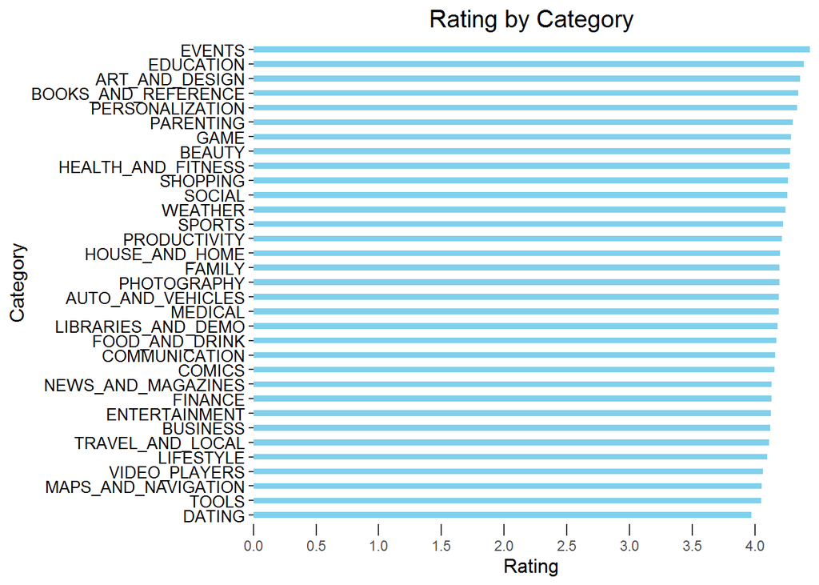

```r
library(ggplot2)
dataset %>% filter(dataset$Category != "") %>% group_by(Category) %>% dplyr::summarise(rating = mean(Rating,na.rm = TRUE)) %>% mutate(Category = reorder(Category,rating)) %>% ggplot()+
geom_bar(aes(Category,rating),stat = "identity",fill = "#01a2d9",alpha = 0.5, width = 0.4)+
coord_flip()+
  scale_y_continuous(breaks = seq(0,4.5,0.5),expand = c(0,0))+
  theme(plot.title = element_text(hjust = 0.5,size = 15))+
  ggtitle("Rating by Category")+
  ylab("Rating")+
  theme(legend.position = "none",
        panel.grid = element_blank(),
        axis.text.y = element_text(color = "black",size =10,hjust = 1),
        axis.ticks.length.x = unit(0.5,"lines"),
        axis.title = element_text(size = 12),
        panel.background = element_rect(fill = "white"))
```

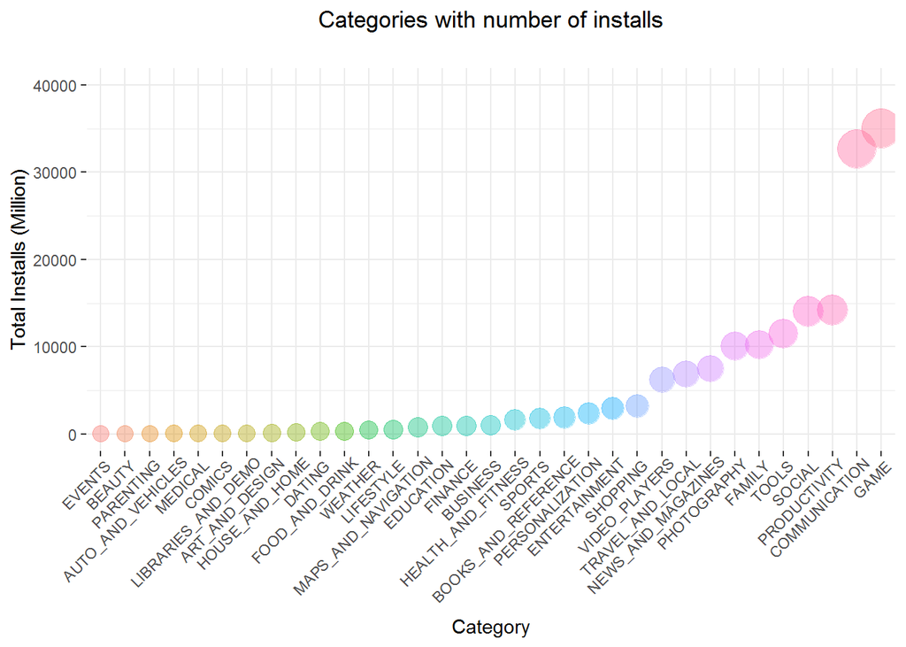

```r
dataset = na.omit(dataset)
dataset %>%
  filter(dataset$Category!= "") %>%
  group_by(Category) %>%
  dplyr::summarise(Totalinstalls = sum(Installsnew,na.rm = TRUE)) %>%
  mutate(Category = reorder(Category,Totalinstalls))%>%
  mutate(Totalinstalls = Totalinstalls / 1000000) %>%
  ggplot()+
  theme_bw()+
  ggtitle("Categories with number of installs")+
  geom_point(aes(Category,Totalinstalls,color = Category,size = Totalinstalls),alpha = 0.4)+
  scale_size_continuous(range = c(4,10))+
  scale_y_continuous(limits = c(0,40000))+
  ylab("Total Installs (Million)")+
  theme(
    axis.text.x = element_text(angle = 45,hjust = 0.95),
    legend.position = "none",
    plot.title = element_text(hjust = 0.5,margin = margin(b = 20)),
    panel.border = element_rect(color = "white"),
  )
```

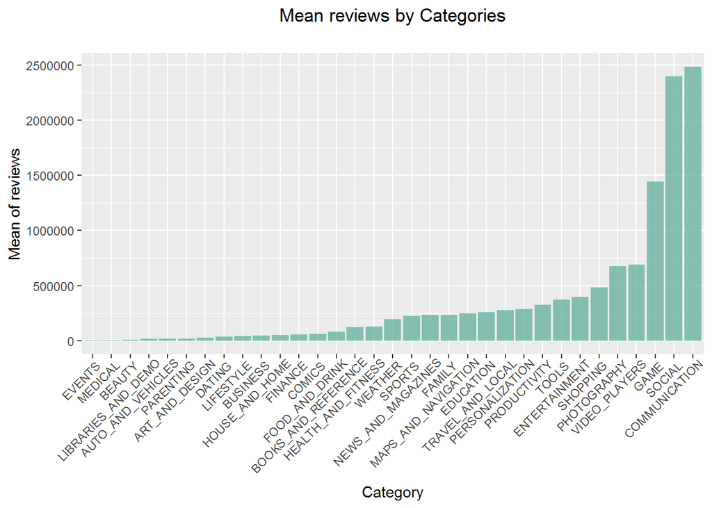

```r
green_color <- "#69b3a2"
dataset$Reviews = as.numeric(dataset$Reviews)
dataset %>%
  filter(dataset$Category!= "") %>%
  group_by(Category) %>%
  dplyr::summarise(Mean_reviews = mean(Reviews,na.rm = TRUE)) %>%
  mutate(Category = reorder(Category,Mean_reviews))%>%
  ggplot(aes(x = Mean_reviews,y = Category),alpha = 0.4) +
  geom_col(fill=green_color,alpha=0.8) +
  coord_flip() +
  labs(x="Mean of reviews",y="Category")+
  ggtitle("Mean reviews by Categories")+
   theme(
    axis.text.x = element_text(angle = 45,hjust = 0.95),
    legend.position = "none",
    plot.title = element_text(hjust = 0.5,margin = margin(b = 20)),
  )
```

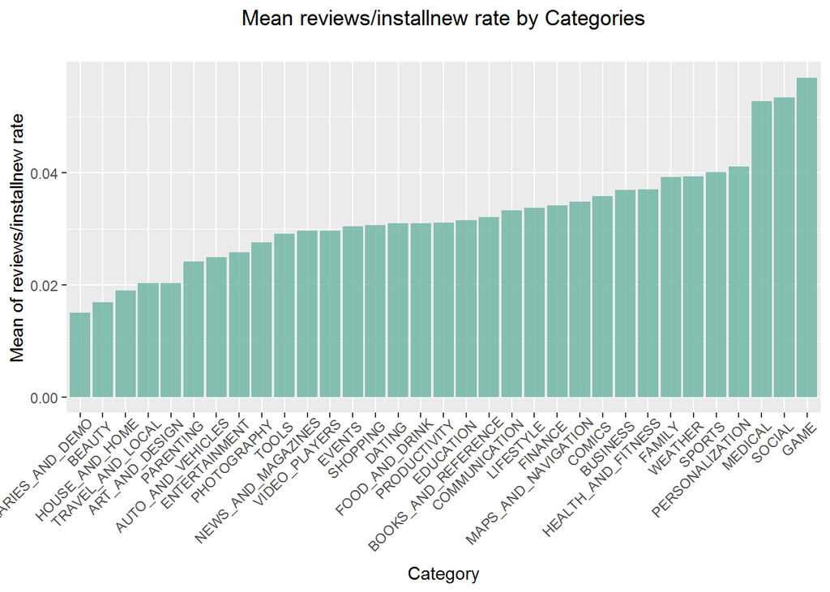

```r
dataset %>%
  filter(dataset$Category!= "") %>%
  group_by(Category) %>%
  dplyr::summarise(Mean_reviewsinstall_rate = mean(Reviews/Installsnew,na.rm = TRUE)) %>%
  mutate(Category = reorder(Category,Mean_reviewsinstall_rate ))%>%
  ggplot(aes(x = Mean_reviewsinstall_rate ,y = Category),alpha = 0.4) +
  geom_col(fill="#69b3a2",alpha=0.8) +
  coord_flip() +
  labs(x="Mean of reviews/installnew rate",y="Category")+
  ggtitle("Mean reviews/installnew rate by Categories")+
   theme(
    axis.text.x = element_text(angle = 45,hjust = 0.95),
    legend.position = "none",
    plot.title = element_text(hjust = 0.5,margin = margin(b = 20)),
  )
```

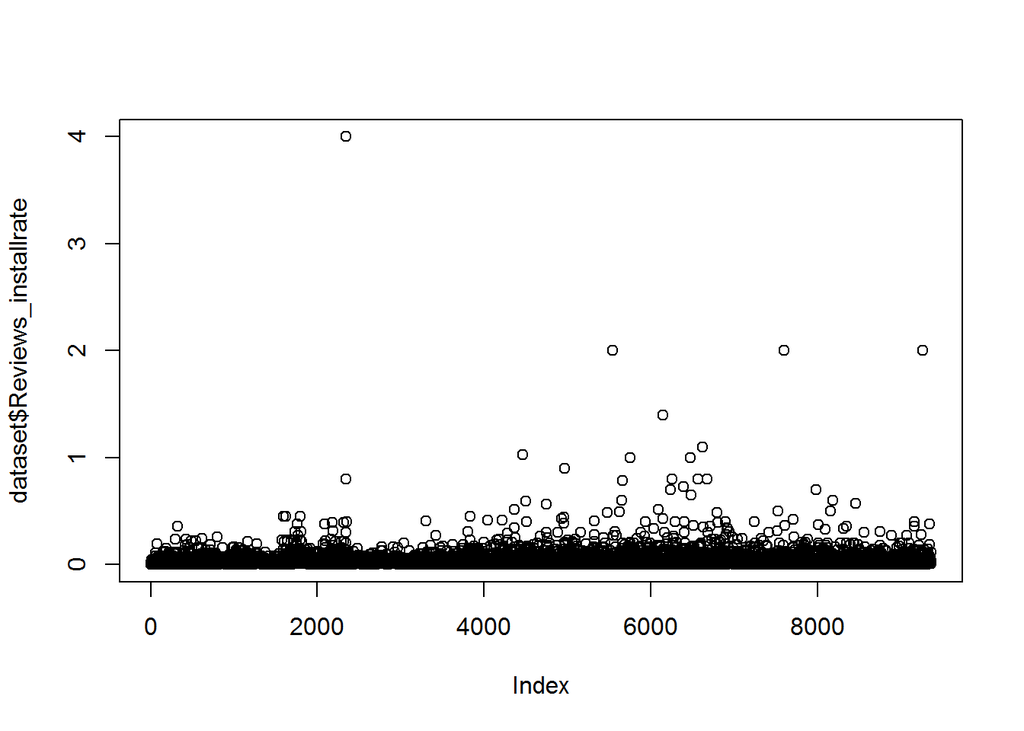

```r
dataset <- dataset %>% mutate(Reviews_installrate = Reviews/Installsnew)
plot(dataset$Reviews_installrate)
```

```r
#installnew <500 miss
```

```r
df <- dataset %>% mutate(Reviews_installrate = Reviews/Installsnew) %>% filter(Installsnew >=10000)
```

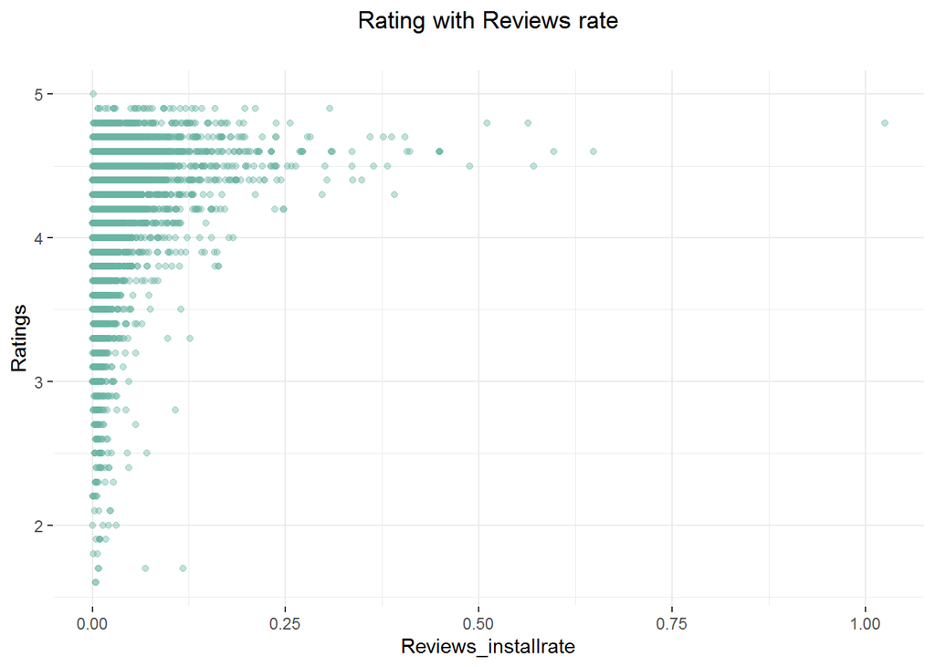

```r
df %>%ggplot()+
  theme_bw()+
  ggtitle("Rating with Reviews rate")+
  geom_point(aes(Reviews_installrate,Rating),color = "#69b3a2",alpha = 0.4)+
  #scale_size_continuous(range = c(4,10))+
 # scale_y_continuous(limits = c(0,40000))+
  ylab("Ratings")+
  theme(
    legend.position = "none",
    plot.title = element_text(hjust = 0.5,margin = margin(b = 20)),
    panel.border = element_rect(color = "white")
  )
```

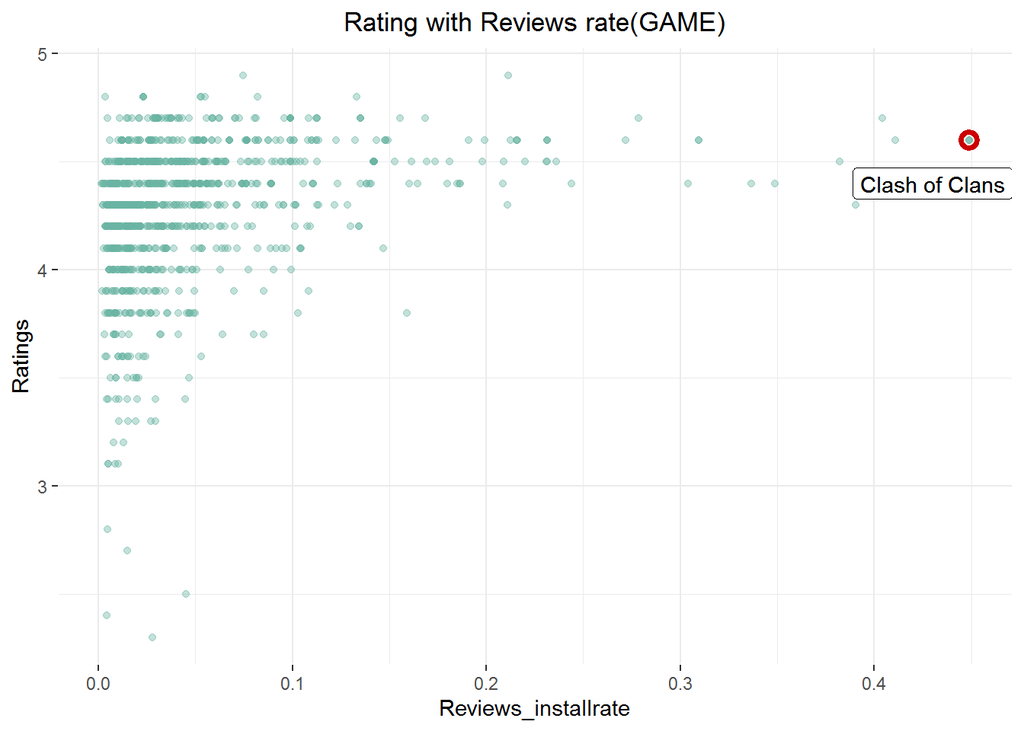

```r
df %>% filter(Category == "GAME")%>%
  ggplot()+
  theme_bw()+
  ggtitle("Rating with Reviews rate(GAME)")+
  geom_point(aes(Reviews_installrate,Rating),color = "#69b3a2",alpha = 0.4)+
  geom_point(aes(x = 0.4489172, y = 4.6,stroke = 2),shape = 1, color="#CC0000", size=2.5)+  geom_label(label='  Clash of Clans',x = 0.43, y = 4.4,color='black', alpha= 0.5) +
  #scale_size_continuous(range = c(4,10))+
 # scale_y_continuous(limits = c(0,40000))+
  ylab("Ratings")+
  theme(
    legend.position = "none",
    plot.title = element_text(hjust = 0.5),
    panel.border = element_rect(color = "white")
  )
```

#instogram/ Facebookd

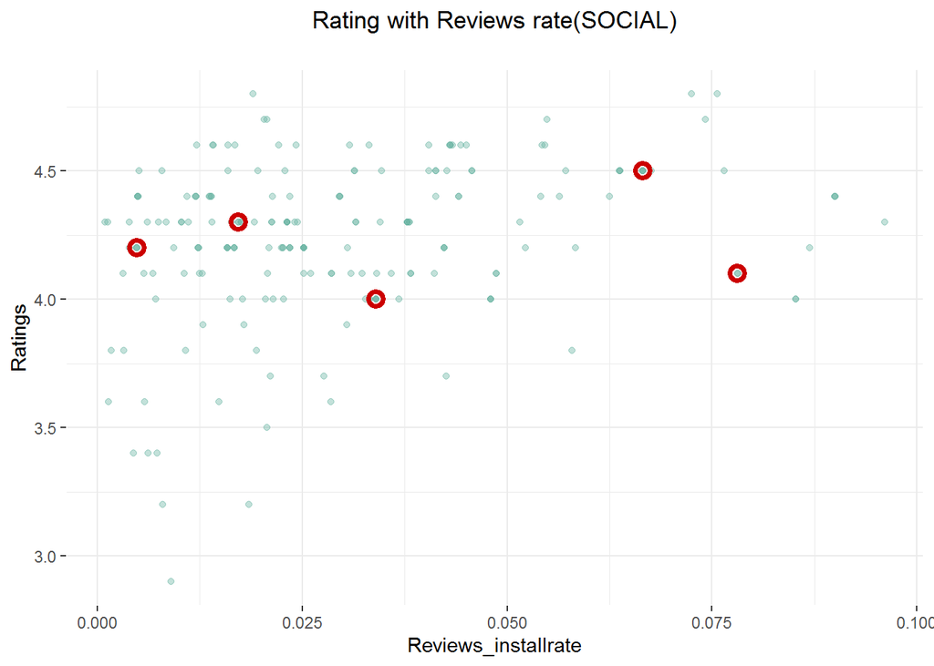

```r
df %>% filter(Category == "SOCIAL" & Reviews_installrate <=0.1)%>%
  ggplot()+
  theme_bw()+
  ggtitle("Rating with Reviews rate(SOCIAL)")+
  geom_point(aes(Reviews_installrate,Rating),color = "#69b3a2",alpha = 0.4)+
  geom_point(aes(x = 0.06657731, y = 4.5,stroke = 2),shape = 1, color="#CC0000", size=2.5)+
  #geom_label(label='Instagram',x = 0.07, y = 4.45,color='black', alpha= 0.5)+
  geom_point(aes(x = 0.07812821, y = 4.1,stroke = 2),shape = 1, color="#CC0000", size=2.5)+
  #geom_label(label='Facebook',x = 0.075, y = 4.15,color='black', alpha= 0.5)+
  geom_point(aes(x = 0.034029574, y = 4.0,stroke = 2),shape = 1, color="#CC0000", size=2.5)+
   #geom_label(label='Snapchat',x = 0.035, y = 4.05,color='black', alpha= 0.5)+
  geom_point(aes(x = 0.004831125, y = 4.2,stroke = 2),shape = 1, color="#CC0000", size=2.5)+
   #geom_label(label='Google',x = 0.01, y = 4.15,color='black', alpha= 0.5)+
  geom_point(aes(x = 0.017212518, y = 4.3,stroke = 2),shape = 1, color="#CC0000", size=2.5)+
  #geom_label(label='Facebook lite',x = 0.019, y = 4.25,color='black', alpha= 0.5)+
  #scale_size_continuous(range = c(4,10))+
 # scale_y_continuous(limits = c(0,40000))+
  ylab("Ratings")+
  theme(
    legend.position = "none",
    plot.title = element_text(hjust = 0.5,margin = margin(b = 20)),
    panel.border = element_rect(color = "white")
    )
```

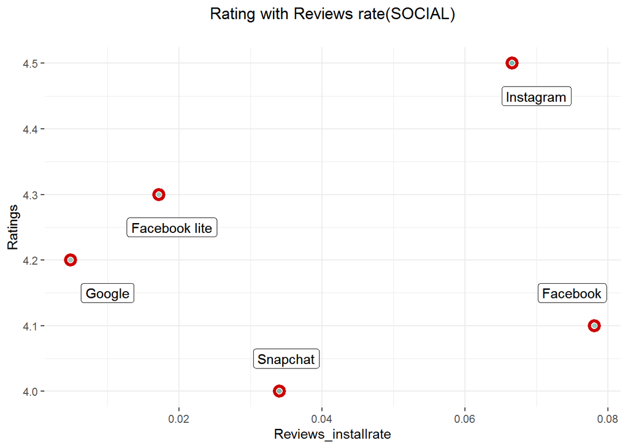

```r
df %>% filter(Category == "SOCIAL" & Reviews_installrate <=0.1 & Size == "Varies with device" & Installsnew > 2e+8)%>%
  ggplot()+
  theme_bw()+
  ggtitle("Rating with Reviews rate(SOCIAL)")+
  geom_point(aes(Reviews_installrate,Rating),color = "#69b3a2",alpha = 0.4)+
  geom_point(aes(x = 0.06657731, y = 4.5,stroke = 2),shape = 1, color="#CC0000", size=2.5)+
  geom_label(label='Instagram',x = 0.07, y = 4.45,color='black', alpha= 0.5)+
  geom_point(aes(x = 0.07812821, y = 4.1,stroke = 2),shape = 1, color="#CC0000", size=2.5)+
  geom_label(label='Facebook',x = 0.075, y = 4.15,color='black', alpha= 0.5)+
  geom_point(aes(x = 0.034029574, y = 4.0,stroke = 2),shape = 1, color="#CC0000", size=2.5)+
   geom_label(label='Snapchat',x = 0.035, y = 4.05,color='black', alpha= 0.5)+
  geom_point(aes(x = 0.004831125, y = 4.2,stroke = 2),shape = 1, color="#CC0000", size=2.5)+
   geom_label(label='Google',x = 0.01, y = 4.15,color='black', alpha= 0.5)+
  geom_point(aes(x = 0.017212518, y = 4.3,stroke = 2),shape = 1, color="#CC0000", size=2.5)+
  geom_label(label='Facebook lite',x = 0.019, y = 4.25,color='black', alpha= 0.5)+
  #scale_size_continuous(range = c(4,10))+
 # scale_y_continuous(limits = c(0,40000))+
  ylab("Ratings")+
  theme(
    legend.position = "none",
    plot.title = element_text(hjust = 0.5,margin = margin(b = 20)),
    panel.border = element_rect(color = "white")
    )
```

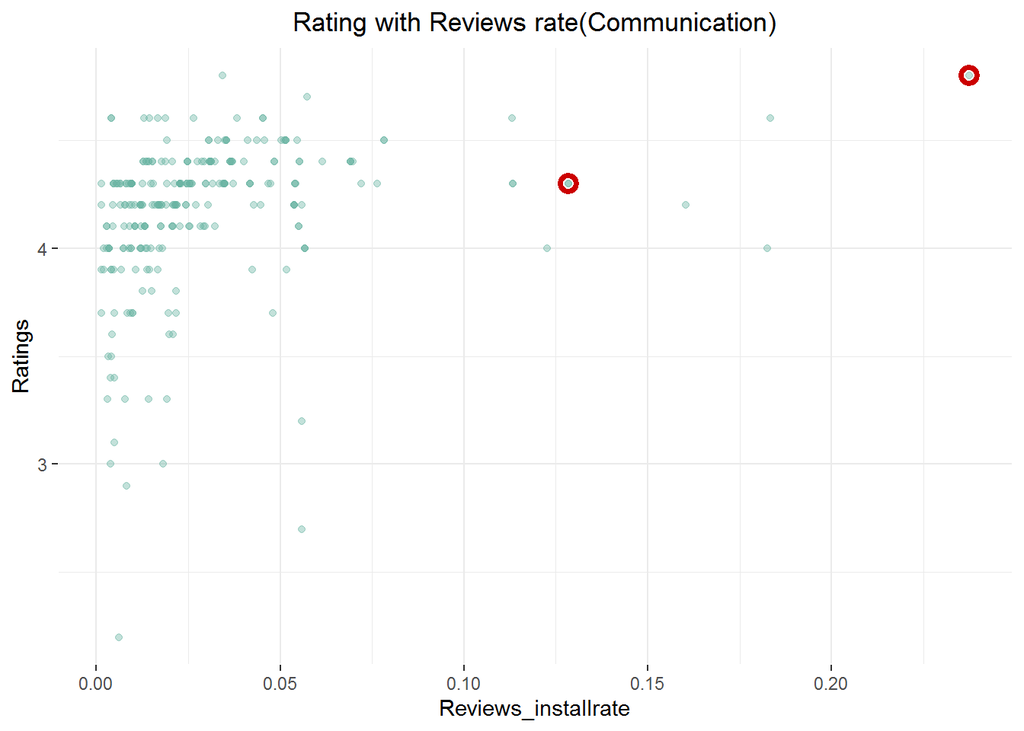

```r
df %>% filter(Category == "COMMUNICATION")%>%
  ggplot()+
  theme_bw()+
  ggtitle("Rating with Reviews rate(Communication)")+
  geom_point(aes(Reviews_installrate,Rating),color = "#69b3a2",alpha = 0.4)+
  geom_point(aes(x = 0.1284286, y = 4.3,stroke = 2),shape = 1, color="#CC0000", size=2.5)+
  geom_point(aes(x =0.2374680, y = 4.8,stroke = 2),shape = 1, color="#CC0000", size=2.5)+
  #scale_size_continuous(range = c(4,10))+
 # scale_y_continuous(limits = c(0,40000))+
  ylab("Ratings")+
  theme(
    legend.position = "none",
    plot.title = element_text(hjust = 0.5),
    panel.border = element_rect(color = "white")
  )
```

#dummy variable

```r
dataset$Content.Rating[dataset$Content.Rating == "Everyone 10+"] <- "Everyone_10"
dataset$Content.Rating[dataset$Content.Rating == "Mature 17+"] <- "Mature_17"
dataset$Content.Rating[dataset$Content.Rating == "Adults only 18+"] <- "Adults_only_18"
```

```r
library(fastDummies)
data  = dummy_cols(dataset, select_columns = c("Category", "Content.Rating"),remove_first_dummy = TRUE)
```

#charcater varit

```r
data = subset(data, select = -c(Category, Content.Rating))
data$Type[dataset$Type == "Free"] = 0
data$Type[dataset$Type == "Paid"] = 1
#delete varies with device
#table(dataset$Sizenew)
library(tidyr)
data = separate(data, Size,into = c("Sizenew"),sep = "M")
data = data[!data$Sizenew == "Varies with device",]
```

```r
dataset1 = separate(data, Sizenew, into = c("Sizenew1"),sep = "k")
k.index = which(data$Sizenew != dataset1$Sizenew1)
dataset1$Sizenew1 = as.numeric(dataset1$Sizenew1)
for (i in k.index){
  dataset1$Sizenew1[i] = (dataset1$Sizenew1[i]/1024)
}
data$Sizenew = dataset1$Sizenew1
```

```r
data$Android.Ver = substr(data$Android.Ver, 1,3)
data= data[!data$Android.Ver == "Var",]
data$Android.Ver = as.numeric(data$Android.Ver)
data$Type = as.numeric(data$Type)
data = na.omit(data)
```

```r
data = data%>% filter(data$Installsnew >= 1000)
data = data %>% mutate(Rating_install_target = data$Rating*data$Reviews_installrate)
data = subset(data, select = -c(App,Rating,Reviews,Installsnew,add_years,Reviews_installrate))
```

```r
library(OutlierDetection)
library(OutliersO3)
library(outliers)
a = nn(data,k=4)
for (i in a[2]){
  data = data[-i,]
}
```

#normalized 1:4 conclumn

```r
tmp = rep(0,4)
for (i in 1:4){
  tmp[i] = max(data[,i])
  data[,i] = data[,i]/tmp[i]
}
```

```r
data = subset(data, select = -c(Content.Rating_Unrated))
```

```r
summary(data)
```

```
##     Sizenew               Type          Android.Ver       add_month
##  Min.   :0.0001074   Min.   :0.00000   Min.   :0.1250   Min.   :0.08333
##  1st Qu.:0.0540000   1st Qu.:0.00000   1st Qu.:0.5000   1st Qu.:0.41667
##  Median :0.1400000   Median :0.00000   Median :0.5125   Median :0.58333
##  Mean   :0.2276671   Mean   :0.05492   Mean   :0.4825   Mean   :0.53248
##  3rd Qu.:0.3300000   3rd Qu.:0.00000   3rd Qu.:0.5250   3rd Qu.:0.66667
##  Max.   :1.0000000   Max.   :1.00000   Max.   :1.0000   Max.   :1.00000
##  Category_AUTO_AND_VEHICLES Category_BEAUTY   Category_BOOKS_AND_REFERENCE
##  Min.   :0.000000           Min.   :0.00000   Min.   :0.00000
##  1st Qu.:0.000000           1st Qu.:0.00000   1st Qu.:0.00000
##  Median :0.000000           Median :0.00000   Median :0.00000
##  Mean   :0.008186           Mean   :0.00506   Mean   :0.01979
##  3rd Qu.:0.000000           3rd Qu.:0.00000   3rd Qu.:0.00000
##  Max.   :1.000000           Max.   :1.00000   Max.   :1.00000
##  Category_BUSINESS Category_COMICS  Category_COMMUNICATION Category_DATING
##  Min.   :0.00000   Min.   :0.0000   Min.   :0.00000        Min.   :0.00000
##  1st Qu.:0.00000   1st Qu.:0.0000   1st Qu.:0.00000        1st Qu.:0.00000
##  Median :0.00000   Median :0.0000   Median :0.00000        Median :0.00000
##  Mean   :0.02932   Mean   :0.0064   Mean   :0.02709        Mean   :0.02203
##  3rd Qu.:0.00000   3rd Qu.:0.0000   3rd Qu.:0.00000        3rd Qu.:0.00000
##  Max.   :1.00000   Max.   :1.0000   Max.   :1.00000        Max.   :1.00000
##  Category_EDUCATION Category_ENTERTAINMENT Category_EVENTS    Category_FAMILY
##  Min.   :0.00000    Min.   :0.00000        Min.   :0.000000   Min.   :0.0000
##  1st Qu.:0.00000    1st Qu.:0.00000        1st Qu.:0.000000   1st Qu.:0.0000
##  Median :0.00000    Median :0.00000        Median :0.000000   Median :0.0000
##  Mean   :0.01548    Mean   :0.01206        Mean   :0.004167   Mean   :0.2064
##  3rd Qu.:0.00000    3rd Qu.:0.00000        3rd Qu.:0.000000   3rd Qu.:0.0000
##  Max.   :1.00000    Max.   :1.00000        Max.   :1.000000   Max.   :1.0000
##  Category_FINANCE  Category_FOOD_AND_DRINK Category_GAME
##  Min.   :0.00000   Min.   :0.00000         Min.   :0.0000
##  1st Qu.:0.00000   1st Qu.:0.00000         1st Qu.:0.0000
##  Median :0.00000   Median :0.00000         Median :0.0000
##  Mean   :0.03617   Mean   :0.01146         Mean   :0.1219
##  3rd Qu.:0.00000   3rd Qu.:0.00000         3rd Qu.:0.0000
##  Max.   :1.00000   Max.   :1.00000         Max.   :1.0000
##  Category_HEALTH_AND_FITNESS Category_HOUSE_AND_HOME
##  Min.   :0.00000             Min.   :0.000000
##  1st Qu.:0.00000             1st Qu.:0.000000
##  Median :0.00000             Median :0.000000
##  Mean   :0.02828             Mean   :0.008186
```

[output cut: 36 more lines]

```
##  Max.   :1.00000           Max.   :1.00000        Max.   :1.000000
##  Content.Rating_Everyone Content.Rating_Everyone_10 Content.Rating_Mature_17
##  Min.   :0.0000          Min.   :0.00000            Min.   :0.00000
##  1st Qu.:1.0000          1st Qu.:0.00000            1st Qu.:0.00000
##  Median :1.0000          Median :0.00000            Median :0.00000
##  Mean   :0.8102          Mean   :0.04004            Mean   :0.04271
##  3rd Qu.:1.0000          3rd Qu.:0.00000            3rd Qu.:0.00000
##  Max.   :1.0000          Max.   :1.00000            Max.   :1.00000
##  Content.Rating_Teen Rating_install_target
##  Min.   :0.0000      Min.   :0.0004225
##  1st Qu.:0.0000      1st Qu.:0.0329697
##  Median :0.0000      Median :0.0687904
##  Mean   :0.1067      Mean   :0.1269376
##  3rd Qu.:0.0000      3rd Qu.:0.1485046
##  Max.   :1.0000      Max.   :2.0651188
```

```r
lm.fit = lm(data$Rating_install_target~., data = data)
summary(lm.fit)
```

```
##
## Call:
## lm(formula = data$Rating_install_target ~ ., data = data)
##
## Residuals:
##      Min       1Q   Median       3Q      Max
## -0.37547 -0.07419 -0.03871  0.02453  1.83219
##
## Coefficients:
##                                Estimate Std. Error t value Pr(>|t|)
## (Intercept)                   0.1211145  0.1158781   1.045  0.29597
## Sizenew                       0.0952162  0.0100016   9.520  < 2e-16 ***
## Type                          0.2445598  0.0087854  27.837  < 2e-16 ***
## Android.Ver                   0.0657022  0.0209813   3.131  0.00175 **
## add_month                     0.0216662  0.0092512   2.342  0.01921 *
## Category_AUTO_AND_VEHICLES    0.0116628  0.0299839   0.389  0.69731
## Category_BEAUTY              -0.0091299  0.0344010  -0.265  0.79071
## Category_BOOKS_AND_REFERENCE  0.0399991  0.0250688   1.596  0.11063
## Category_BUSINESS             0.0085512  0.0237937   0.359  0.71932
## Category_COMICS               0.0205362  0.0322951   0.636  0.52487
## Category_COMMUNICATION        0.0178099  0.0240178   0.742  0.45840
## Category_DATING               0.0256472  0.0273736   0.937  0.34883
## Category_EDUCATION            0.0428555  0.0261272   1.640  0.10100
## Category_ENTERTAINMENT       -0.0071131  0.0276592  -0.257  0.79706
## Category_EVENTS               0.0053950  0.0366709   0.147  0.88304
## Category_FAMILY               0.0182108  0.0214271   0.850  0.39541
## Category_FINANCE              0.0465723  0.0232930   1.999  0.04560 *
## Category_FOOD_AND_DRINK      -0.0146385  0.0277320  -0.528  0.59762
## Category_GAME                 0.0549943  0.0219686   2.503  0.01233 *
## Category_HEALTH_AND_FITNESS   0.0138325  0.0239207   0.578  0.56310
## Category_HOUSE_AND_HOME      -0.0156401  0.0299798  -0.522  0.60191
## Category_LIBRARIES_AND_DEMO  -0.0043112  0.0293812  -0.147  0.88335
## Category_LIFESTYLE            0.0001165  0.0233410   0.005  0.99602
## Category_MAPS_AND_NAVIGATION -0.0097076  0.0270638  -0.359  0.71984
## Category_MEDICAL             -0.0119036  0.0231931  -0.513  0.60780
## Category_NEWS_AND_MAGAZINES   0.0027830  0.0247256   0.113  0.91039
## Category_PARENTING           -0.0140258  0.0322770  -0.435  0.66391
## Category_PERSONALIZATION      0.0140096  0.0234481   0.597  0.55021
## Category_PHOTOGRAPHY          0.0063400  0.0235255   0.269  0.78756
## Category_PRODUCTIVITY         0.0293071  0.0237287   1.235  0.21684
## Category_SHOPPING            -0.0038737  0.0243441  -0.159  0.87358
## Category_SOCIAL               0.0706125  0.0249951   2.825  0.00474 **
## Category_SPORTS               0.0443672  0.0234869   1.889  0.05893 .
## Category_TOOLS                0.0112386  0.0219654   0.512  0.60891
## Category_TRAVEL_AND_LOCAL    -0.0177697  0.0248076  -0.716  0.47383
## Category_VIDEO_PLAYERS        0.0013963  0.0260233   0.054  0.95721
## Category_WEATHER              0.0832415  0.0310745   2.679  0.00741 **
## Content.Rating_Everyone      -0.0990402  0.1133980  -0.873  0.38248
## Content.Rating_Everyone_10   -0.0465954  0.1138170  -0.409  0.68227
## Content.Rating_Mature_17     -0.1012711  0.1140108  -0.888  0.37443
## Content.Rating_Teen          -0.0584523  0.1135123  -0.515  0.60661
## ---
## Signif. codes:  0 '***' 0.001 '**' 0.01 '*' 0.05 '.' 0.1 ' ' 1
##
## Residual standard error: 0.1592 on 6678 degrees of freedom
## Multiple R-squared:  0.1547, Adjusted R-squared:  0.1497
## F-statistic: 30.56 on 40 and 6678 DF,  p-value: < 2.2e-16
```

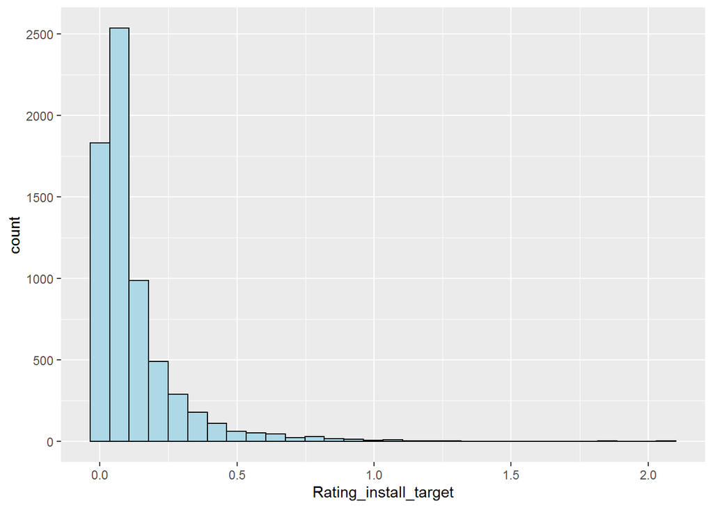

```r
library(ggplot2)
data %>% ggplot(aes(x=Rating_install_target)) + geom_histogram(color="black", fill="lightblue")+
  theme(legend.position="none")
```

```r
set.seed(13)
train = sample(nrow(data),0.6*nrow(data))
data.Train = data[train,]
data.testX=data[-train,"Rating_install_target"]
```

#xgboost

```r
library(xgboost)
set.seed(1)
RMSE_train = rep(0,20)
RMSE_validation = rep(0,20)
RMSE_test = rep(0,20)
eta_variable = seq(0.1,0.29,by = 0.01)
#max_depth_variable = seq(1,10, by = 1)
#subsample_varibale = seq(0.5,1,by = 0.1)
for (i in 1:20){
 xgbcv = xgb.cv(data = data.matrix(data.Train[,-41]),
 label = data.Train$Rating_install_target,
 eta = eta_variable[i],
 max_depth = 8,
 nround = 30,
 subsample = 1,
 nfold=5,
 early_stopping_rounds = 3,
objective = "reg:squarederror",
)
RMSE_train[i] = min(xgbcv$evaluation_log$train_rmse_mean)
RMSE_validation[i] = min(xgbcv$evaluation_log$test_rmse_mean)
xgb = xgboost(data = data.matrix(data.Train[,-41]),
 label = data.Train$Rating_install_target,
 eta = eta_variable[i],
 max_depth = 8,
 nround = 30,
 subsample = 1,
 early_stopping_rounds = 3,
objective = "reg:squarederror",
)
datamodel_xgboost = predict(xgb, newdata = data.matrix(data[-train,-41]))
RMSE_test[i] = mean((datamodel_xgboost -data.testX)^2)^0.5
}
```

[output not shown]

[output cut: 75 more lines]

[output not shown]

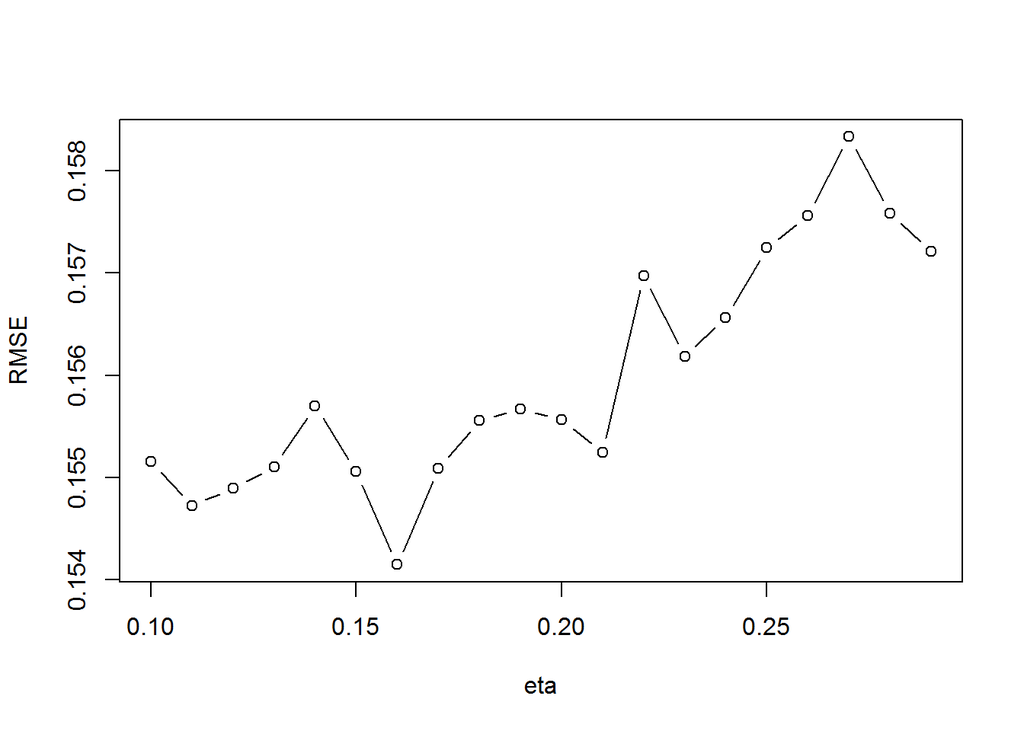

```r
plot(eta_variable ,RMSE_test, xlab = "eta", ylab = "RMSE",type = "b")
```

```r
library(xgboost)
set.seed(1)
xgb = xgboost(data = data.matrix(data.Train[,-41]),
 label = data.Train$Rating_install_target,
 eta = 0.2,
 max_depth = 8,
 nround = 30,
 subsample = 1,
 early_stopping_rounds = 3,
objective = "reg:squarederror",
)
```

```
## Will train until train_rmse hasn't improved in 3 rounds.
##
```

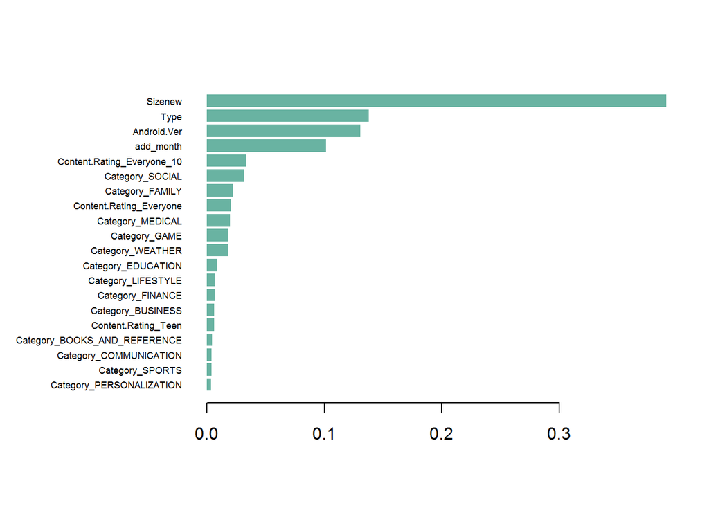

```r
names = dimnames(data.matrix(data.Train[,-41]))[[2]]
importance_matrix = xgb.importance(names, model = xgb)
xgb.plot.importance(importance_matrix[1:20,], col = green_color)
```

```r
datamodel_xgboost = predict(xgb, newdata = data.matrix(data[-train,-41]))
mean((datamodel_xgboost -data.testX)^2)^0.5
```

```
## [1] 0.1555676
```

```r
Target_hat = predict(xgb, newdata = data.matrix(data[train,-41]))
data_s = data.frame(data[train,],Target_hat)
data_s$Sizenew_raw = data_s$Sizenew*100
data_s$Type_raw = data_s$Type*1
data_s$Android.Ver_raw = data_s$Android.Ver*8
data_s$add_month_raw = data_s$add_month*12
```

```r
data_s <- data_s %>%
  mutate(Content.Rating_Adults_only_18 = ifelse((Content.Rating_Everyone + Content.Rating_Everyone_10 + Content.Rating_Mature_17 + Content.Rating_Teen) == 0 , 1, 0))
attach(data_s)
```

```r
data_s <- data_s %>%
  mutate(Category_ART_AND_DESIGN = ifelse((Category_AUTO_AND_VEHICLES + Category_BEAUTY + Category_BOOKS_AND_REFERENCE + Category_BUSINESS + Category_COMICS +
Category_COMMUNICATION +Category_DATING+Category_EDUCATION+
Category_ENTERTAINMENT+Category_EVENTS+Category_FAMILY+
Category_FINANCE+Category_FOOD_AND_DRINK+Category_GAME+
Category_HEALTH_AND_FITNESS+  Category_HOUSE_AND_HOME     +Category_LIBRARIES_AND_DEMO +
Category_LIFESTYLE          +Category_MAPS_AND_NAVIGATION+Category_MEDICAL            +
Category_NEWS_AND_MAGAZINES +Category_PARENTING          +Category_PERSONALIZATION    +
Category_PHOTOGRAPHY        +Category_PRODUCTIVITY       +Category_SHOPPING           +
Category_SOCIAL             +Category_SPORTS             +Category_TOOLS              +
Category_TRAVEL_AND_LOCAL   +Category_VIDEO_PLAYERS      +Category_WEATHER) == 0 , 1, 0))


# function to reconstruct from dummy
catmaker <- function(data, varnames, catname) {

  data[,catname] <- apply(data[,varnames], 1, function(i) varnames[which(i == 1)])

  return(data)

}
data_s <- catmaker(data =data_s, varnames = c("Content.Rating_Everyone","Content.Rating_Everyone_10",    "Content.Rating_Mature_17","Content.Rating_Teen","Content.Rating_Adults_only_18"), catname = "Content.Rating_raw")
data_s <- catmaker(data=data_s, varnames = c("Category_ART_AND_DESIGN","Category_AUTO_AND_VEHICLES","Category_BEAUTY", "Category_BOOKS_AND_REFERENCE" ,"Category_BUSINESS" ,            "Category_COMICS"
,"Category_COMMUNICATION"  ,      "Category_DATING",               "Category_EDUCATION"
,"Category_ENTERTAINMENT"   ,     "Category_EVENTS" ,              "Category_FAMILY"
,"Category_FINANCE"    ,   "Category_FOOD_AND_DRINK" ,      "Category_GAME"
,"Category_HEALTH_AND_FITNESS",   "Category_HOUSE_AND_HOME",       "Category_LIBRARIES_AND_DEMO"
,"Category_LIFESTYLE" ,           "Category_MAPS_AND_NAVIGATION",  "Category_MEDICAL"
,"Category_NEWS_AND_MAGAZINES",   "Category_PARENTING",            "Category_PERSONALIZATION"
,"Category_PHOTOGRAPHY",          "Category_PRODUCTIVITY",         "Category_SHOPPING"
,"Category_SOCIAL",         "Category_SPORTS",               "Category_TOOLS"
,"Category_TRAVEL_AND_LOCAL",     "Category_VIDEO_PLAYERS",        "Category_WEATHER" ), catname = "Category")

data_s$Content.Rating_raw_cleaned <- stringr::str_remove(data_s$Content.Rating_raw, "Content.Rating_")
data_s$Category_raw_cleaned <- stringr::str_remove(data_s$Category, "Category_")
```

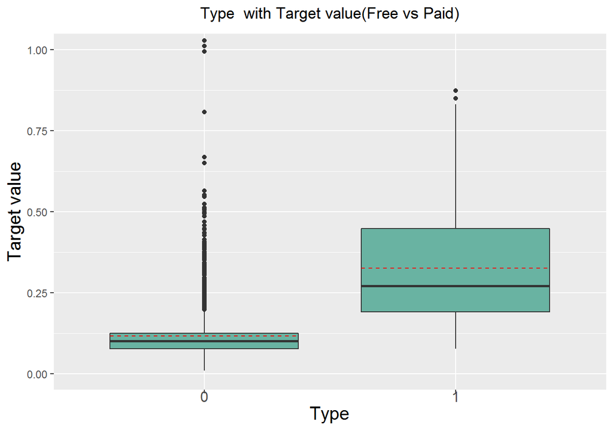

```r
yhat_p0 <- ggplot(data_s, aes(x=as.factor(Type), y=Target_hat)) +
  geom_boxplot(fill=green_color)  +
  coord_cartesian(ylim=c(0, 1)) +
  stat_summary(fun = mean, geom = "errorbar", aes(ymax = ..y.., ymin = ..y..),
                 width = .75, linetype = "dashed",color = "red")+
  labs(x="Type",y="Target value")+
  ggtitle("Type  with Target value(Free vs Paid)")+
   theme(
    axis.text.x = element_text(hjust = 0.5,size =12,vjust=3),
    axis.title.x=element_text(vjust=3,  size=15),
    axis.title.y=element_text(size=15),
    legend.position = "none",
    plot.title = element_text(hjust = 0.5,margin = margin(b = 10)),
  )
yhat_p0
```

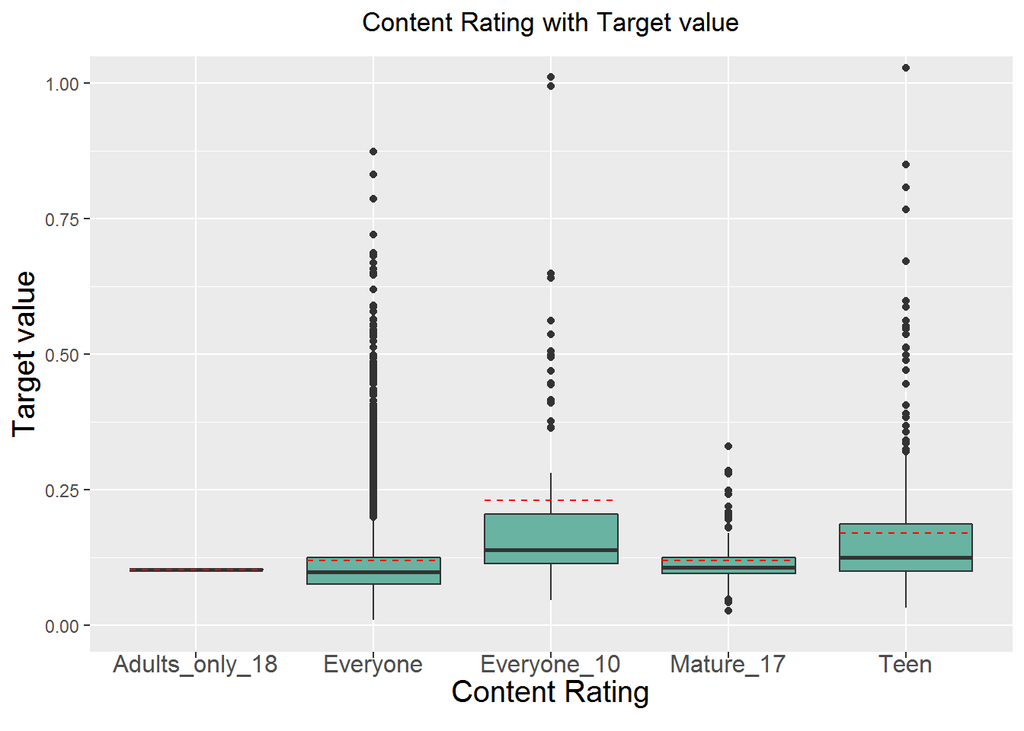

```r
yhat_p <- ggplot(data_s, aes(x=Content.Rating_raw_cleaned, y=Target_hat)) +
  geom_boxplot(fill=green_color)  +
  coord_cartesian(ylim=c(0, 1)) +
  stat_summary(fun = mean, geom = "errorbar", aes(ymax = ..y.., ymin = ..y..),
                 width = .75, linetype = "dashed",color = "red")+
  labs(x="Content Rating",y="Target value")+
  ggtitle("Content Rating with Target value")+
   theme(
    axis.text.x = element_text(hjust = 0.5,size =12,vjust=3),
    axis.title.x=element_text(vjust=3,  size=15),
    axis.title.y=element_text(size=15),
    legend.position = "none",
    plot.title = element_text(hjust = 0.5,margin = margin(b = 10)),
  )
yhat_p
```

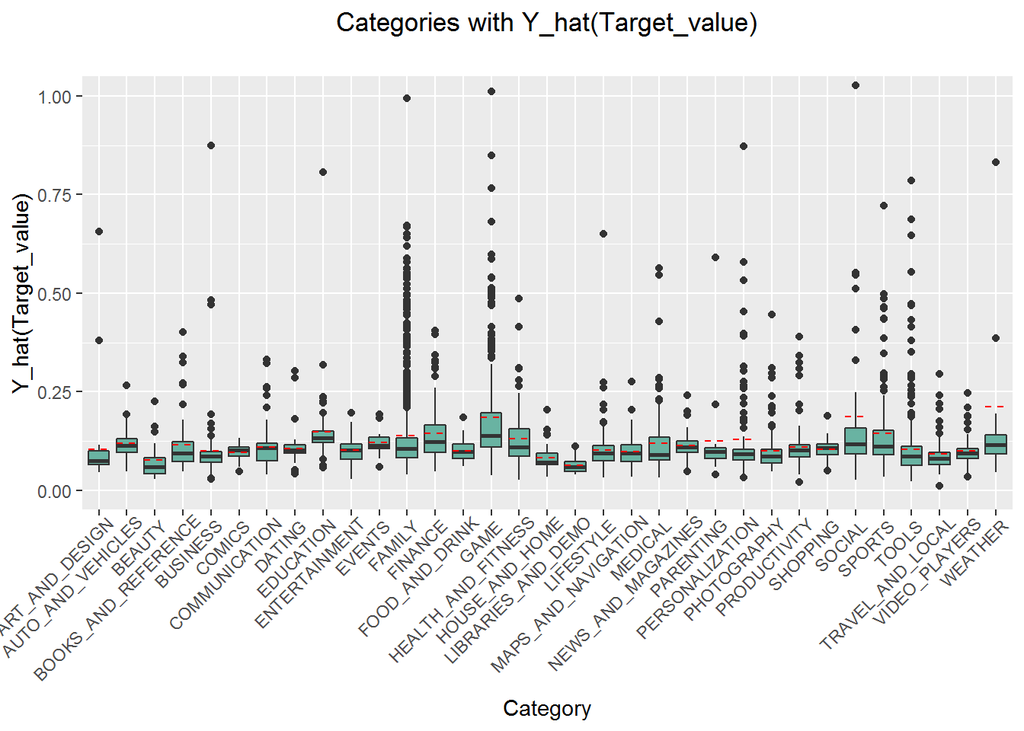

```r
yhat_p2 <- ggplot(data_s, aes(x=Category_raw_cleaned, y=Target_hat)) +
  geom_boxplot(fill=green_color) +
  coord_cartesian(ylim=c(0, 1)) +
  stat_summary(fun = mean, geom = "errorbar", aes(ymax = ..y.., ymin = ..y..),
                 width = .75, linetype = "dashed", color = "red")+
  labs(x="Category",y="Y_hat(Target_value)")+
  ggtitle("Categories with Y_hat(Target_value)")+
   theme(
    axis.text.x = element_text(angle = 45,hjust = 0.95),
    legend.position = "none",
    plot.title = element_text(hjust = 0.5,margin = margin(b = 20)),
  )
yhat_p2
```

```
## geom_path: Each group consists of only one observation. Do you need to adjust
## the group aesthetic?
```

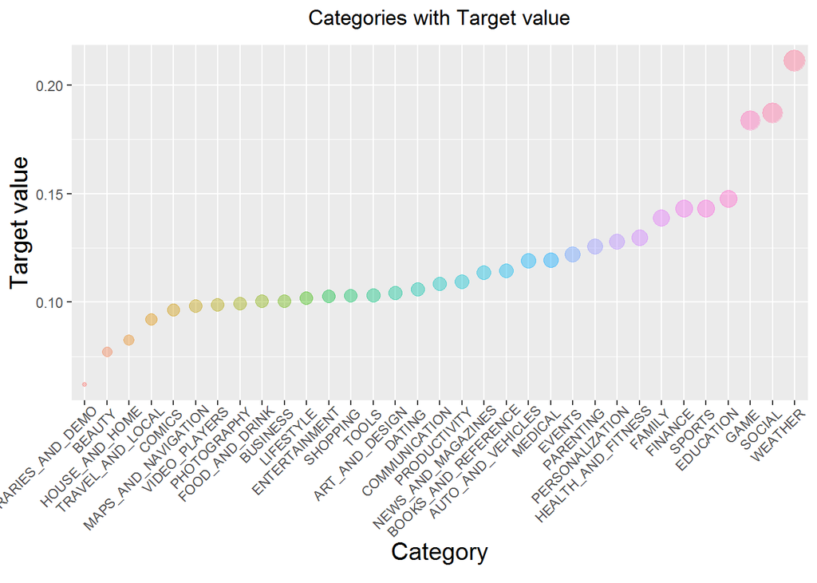

```r
data_s %>% group_by(Category_raw_cleaned) %>% summarise(mean_yhat = mean(Target_hat))%>% mutate(Category_raw_cleaned = reorder(Category_raw_cleaned,mean_yhat)) %>% ungroup() %>%
  ggplot() +
  geom_point(aes(x=as.factor(Category_raw_cleaned), y=mean_yhat,color = Category_raw_cleaned,size = mean_yhat),alpha = 0.4) +
  geom_line(aes(x=as.factor(Category_raw_cleaned), y=mean_yhat), color = green_color)+
    labs(x="Category",y="Target value")+
  ggtitle("Categories with Target value")+
   theme(
    axis.text.x = element_text(angle = 45,hjust = 0.95),
    legend.position = "none",
    axis.title.x=element_text(vjust=3,  size=15),
    axis.title.y=element_text(size=15),
    plot.title = element_text(hjust = 0.5,margin = margin(b = 10)),
  )
```

[figure not shown]

````
# ```{r}
# x<- data.matrix(subset(data.Train, select = -Rating_install_target))
# pdp_plot <- partial(xgb, pred.var = "Sizenew", ice=FALSE, center = TRUE, plot = TRUE, rug = TRUE, alpha=0.1, plot.engine = "ggplot2", train = x,type = "regression")
# pdp_plot
# ```

# ```{r}
# yhat_p2 <- ggpoint(data_s, aes(x=as.factor(add_month_raw), y=Target_hat)) +
#   geom_boxplot(fill=green_color) +
#   coord_cartesian(ylim=c(0, 1)) +
#   stat_summary(fun.y = mean, geom = "errorbar", aes(ymax = ..y.., ymin = ..y..),
#                  width = .75, linetype = "dashed")
# yhat_p2
# ```


```r
data_s %>% group_by(add_month_raw) %>% summarise(mean_yhat = mean(Target_hat)) %>% ungroup() %>%
  ggplot() +  labs(x="Month",y="Target_value")+
  geom_point(aes(x=as.factor(add_month_raw), y=mean_yhat)) +
  geom_line(aes(x=add_month_raw, y=mean_yhat), color = green_color)+
  ggtitle("Month with Target_value")+
   theme(
    axis.text.x = element_text(hjust = 0.5,size =12,vjust=3),
    axis.title.x=element_text(vjust=3,  size=15),
    axis.title.y=element_text(size=15),
    legend.position = "none",
    plot.title = element_text(hjust = 0.5,margin = margin(b = 10)),
  )
````

[figure not shown]

```r
data_s %>% filter(Category_raw_cleaned %in% c("WEATHER","GAME","SOCIAL","SPORTS","FAMILY","EDUCATION")) %>%
  ggplot(aes(x=as.factor(Category_raw_cleaned), y=Target_hat)) +
  geom_boxplot(fill=green_color) +
  coord_cartesian(ylim=c(0, 1)) +
  stat_summary(fun = mean, geom = "errorbar", aes(ymax = ..y.., ymin = ..y..),
                 width = .75, linetype = "dashed", color = "red")+
  labs(x="Category",y="Target value")+
  ggtitle("Categories with Target value")+
  theme(
    axis.text.x = element_text(hjust = 0.5),
    legend.position = "none",
    axis.title.x=element_text(vjust=1,  size=15),
    axis.title.y=element_text(size=15),
    plot.title = element_text(hjust = 0.5,margin = margin(b = 10)),
  )
```

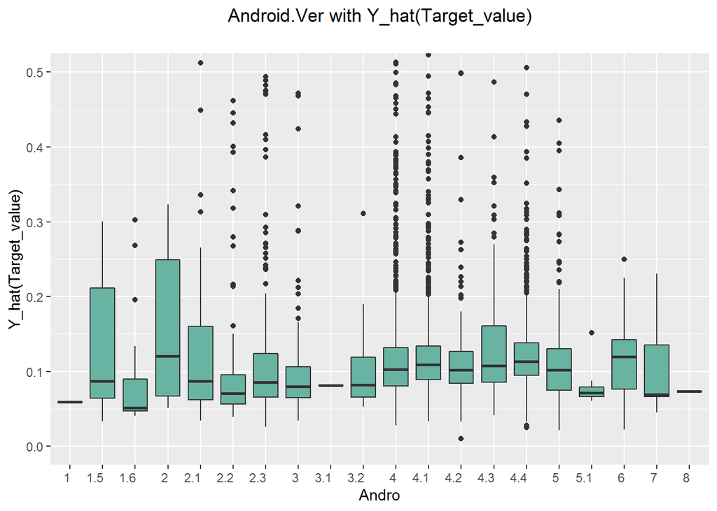

```r
data_s %>% mutate(Android.Ver_raw = as.character(Android.Ver_raw)) %>%
  ggplot(aes(x=Android.Ver_raw, y=Target_hat)) +  labs(x="Andro",y="Y_hat(Target_value)")+
  #geom_point(aes(x=data_s$Android.Ver_raw, y=Target_hat)) +
  geom_boxplot(fill=green_color)+
  ggtitle("Android.Ver with Y_hat(Target_value)")+
   theme(
    axis.text.x = element_text(hjust = 0.95),
    legend.position = "none",
    plot.title = element_text(hjust = 0.5,margin = margin(b = 20)),
  )+ coord_cartesian(ylim=c(0, 0.5))
```

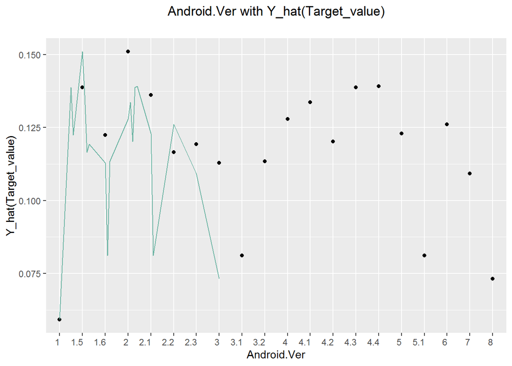

```r
data_s %>% group_by(Android.Ver_raw) %>% summarise(mean_yhat = mean(Target_hat)) %>% ungroup() %>%
  ggplot() +  labs(x="Android.Ver",y="Y_hat(Target_value)")+
  geom_point(aes(x=as.factor(Android.Ver_raw), y=mean_yhat)) +
  geom_line(aes(x=Android.Ver_raw, y=mean_yhat), color = green_color)+
  ggtitle("Android.Ver with Y_hat(Target_value)")+
   theme(
    axis.text.x = element_text(hjust = 0.95),
    legend.position = "none",
    plot.title = element_text(hjust = 0.5,margin = margin(b = 20)),
  )
```

[output not shown]